# Survival Analysis

2022-11-26

## Statistical Analysis

#### Methodology

For our project, we interest using Survival Analysis. Suppose that there is a true survival time, T, as well as a true censoring time, C. The survival time represents the time at which the event of interest occurs: in this dataset, the time at which participant is voted out. The censoring time is the time at which the participant drop out of the game show or survived until the last day of the show.

We observed the Survival Time T and Censoring Time C. Suppose there is a random variable Y

$$Y = min(T,C)$$

In other words, if the event occurs before the censoring such that T $<$ C, then we observed the true survival time T. If censoring occurs before the event such as T $>$ C, then we observe the censoring time. The status indicator as,

$$\delta = \left\{
\begin{array}{ll}
1 & T\leq C \\
0 & T > C \\
\end{array}
\right.$$

Thus, $\delta$ = 1 if we observe the true survival time, and $\delta$ = 0 if we observe the censoring.

## Survival Analysis

```r
## reading in data
survivor_data_final =
  read.csv("data/survivor_data_final.csv")
```

## Create status and time variable

```r
# filtering of seasons moved to data wrangling file
# replaced all survivor_final with survivor_data_final since filtering was moved to use for EDA

status <- c()
time <- c()
for (i in 1:nrow(survivor_data_final))
  {
  if (survivor_data_final[i,17] == "Quit") {
    status[i] <- 0
    time[i] <- survivor_data_final$days_survived[i]
  }
  else if (survivor_data_final[i,17] == "Sole Survivor") {
    status[i] <- 0
    time[i] <- survivor_data_final$days_survived[i]
  }
  else if (survivor_data_final[i,17] == "Runner-up") {
    status[i] <- 0
    time[i] <- survivor_data_final$days_survived[i]
  } else if (survivor_data_final[i,17] == "Co-runner-up") {
    status[i] <- 0
    time[i] <- survivor_data_final$days_survived[i]
  }
  else {
    status[i] <- 1
    time[i] <- survivor_data_final$days_survived[i]
  }
}
survivor_data_final[,25] <- status
survivor_data_final[,26] <- time

colnames(survivor_data_final)[25] <- "status"
colnames(survivor_data_final)[26] <- "time"
```

## Survival Unadjusted Model

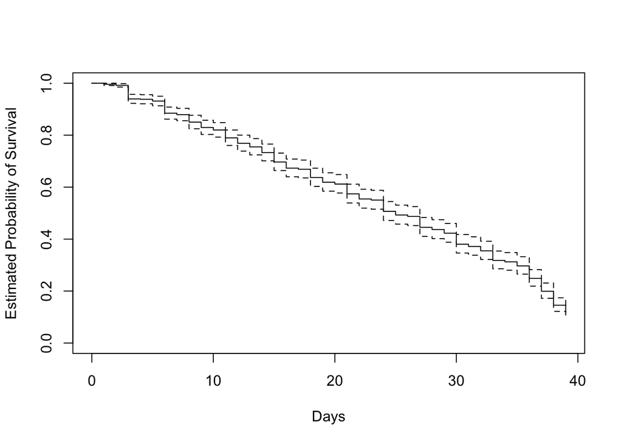

```r
surv_model_unadj <- survfit(Surv(time, status) ~ 1)

plot(surv_model_unadj, xlab = "Days",
     ylab = "Estimated Probability of Survival")
```

```r
surv_model_full <- coxph(data = survivor_data_final,
                         Surv(time, status)~ age_during_show + gender + poc + personality_type_binary + region)

#selectCox(Surv(time, status)~ poc + age_during_show + personality_type_binary + gender + region, data = survivor_data_final)
```